# Replication of BCXL

Shunsuke Matsuno

2020/6/1

# Description

- In this note, we replicate [Bertomeu, Cheynel, Li, and Liang (BCXL; 2020)](https://papers.ssrn.com/sol3/papers.cfm?abstract_id=3680697).
  - This paper proposes an estimation of a manager’s optimal manipulation in a static situation with manipulation costs.

# Required libraries

```r
easypackages::libraries('tidyverse', 'ggplot2', 'BCXL')
```

# Simulate Data

- In this section, we simulate data according to the optimization behavior described in the paper and estimated parameters.

## Parameters

- I use pre-SOX parameters

```r
theta_inv <- 1/0.007
m         <- -0.011
sigma     <- 0.031

theta <- c(theta_inv = theta_inv, m = m, sigma = sigma)
```

## Optimization

- The investor’s pricing function is written in `investor_response.R`.

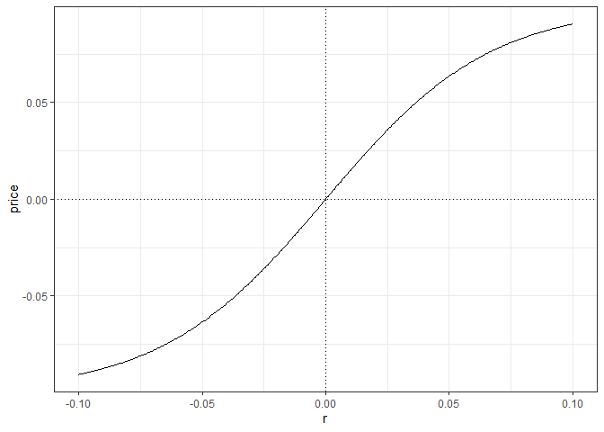

```r
r <- seq(-0.1, 0.1, .0005)
price <- investor_response(r)
qplot(r, price, geom = 'line') +
  geom_vline(xintercept = 0, linetype = 'dotted') +
  geom_hline(yintercept = 0, linetype = 'dotted') +
  theme_bw()
```

## Private Signal

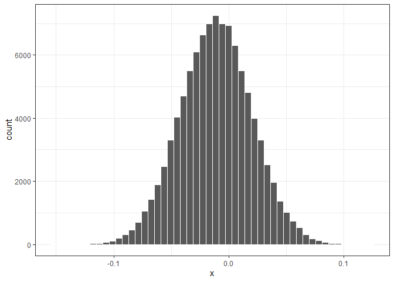

```r
set.seed(1)

N <- 100000    # the number of firms

df_firm <- tibble(
  firm = 1:N,
  x = rnorm(N, m, sigma)
  )

ggplot(df_firm, aes(x = x)) +
  geom_histogram(color="white", bins = 50) +
  theme_bw()
```

- `compute_optimal_reporting.R` computes the optimal manipulation.
  - This function depentds on `compute_utility.R`, which computes the utility for each manipulation and $x$.
  - Please see `Summary of BCXL.pdf` and the original paper for more details.

```r
compute_utility
```

```
function(r, x, theta){
  # This function returns utility of reporting r given cost and x.
  theta_inv <- theta[1]

  benefit <- investor_response(r)
  cost <- theta_inv * (r - x)^2

  return(benefit - cost)
}
<bytecode: 0x00000000269899f8>
<environment: namespace:BCXL>
```

```r
compute_optimal_reporting
```

```
function(theta, x){
  # This function solves the managers optimal manipulation problem

  optim_result <- optim(par = 1,
                        fn = compute_utility,
                        method = 'Brent',
                        lower = -1,
                        upper = 1,
                        theta = theta,
                        x = x,
                        control = list(fnscale = -1))

  return(optim_result$par)

}
<bytecode: 0x0000000026a78bb8>
<environment: namespace:BCXL>
```

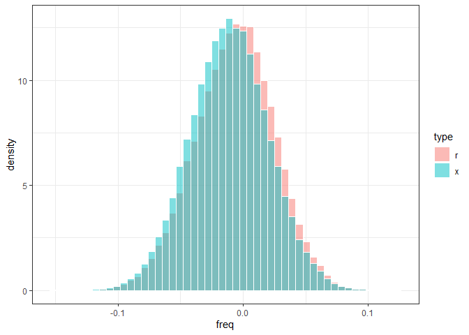

```r
# optimal reporting
df_firm_reported <- df_firm %>%
  mutate(r = map_dbl(.x = x, .f = compute_optimal_reporting, theta = theta)) %>%
  mutate(price = investor_response(r))

# plot
df_firm_reported_plot <- df_firm_reported %>%
  select(firm, x, r) %>%
  pivot_longer(-firm, names_to = "type", values_to = "freq")

ggplot(df_firm_reported_plot, aes(x = freq, fill = type)) +
  geom_histogram(aes(y = ..density..),
                 color    = 'white',
                 position = 'identity',
                 alpha    = .5,
                 bins     = 50) +
  theme_bw()
```

- I regard the simulated reporting as ‘observed’ data.

### Cost parameter

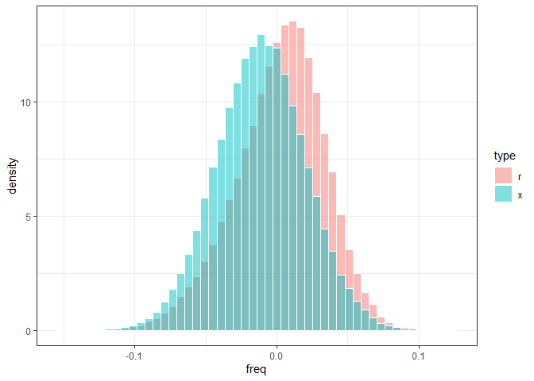

```r
# low cost
plot_r_x(1/3 * theta[1])
```

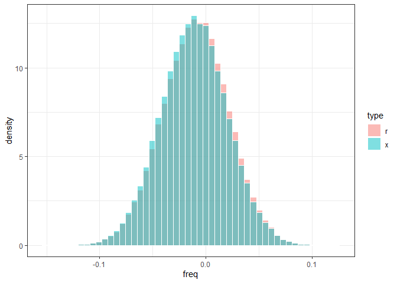

```r
# high cost
plot_r_x(3* theta[1])
```

# Estimation

## Step 1. Estimation of pricing strategy

- I use polynomial regression to estimate $\gamma$.
  - `estimate_gamma_poly.R` computes predicted value of price with polynomial specification and derive its first- and second-order derivatives analytically.

```r
estimate_gamma_poly
```

```
function(df_firm_reported){
  # This function use polynomial regression to obtain
  #  the relationship between price and reported earnings.
  # The first- and second-order derivatives are derived analytically.

  reg <- lm(price ~ poly(r, degree = 3, raw = TRUE), df_firm_reported)
  coef <- reg$coefficients

  pred <- predict(reg, df_firm_reported)
  pred_deriv <- coef[2] + 2 * coef[3] * df_firm_reported$r + 3 * coef[4] * df_firm_reported$r^2
  pred_deriv2 <- 2 * coef[3] + 6 * coef[4] * df_firm_reported$r

  return(list(pred = pred, pred_deriv = pred_deriv, pred_deriv2 = pred_deriv2))
}
<bytecode: 0x0000000029603ad8>
<environment: namespace:BCXL>
```

## Step 2. Parameter Search

- `compue_lkhd.R` returns negative likelihood.

```r
compute_lkhd
```

```
function(theta, df){
  # This function returns negative likelihood.

  # params
  theta_inv <- theta[1]
  m <- theta[2]
  sigma <- theta[3]

  # estimate gamma
  gamma <- estimate_gamma_poly(df_firm_reported)

  lkhd <- df_firm_reported %>%
    mutate(pred_deriv  = gamma$pred_deriv,
           pred_deriv2 = gamma$pred_deriv2) %>%
    mutate(lkhd = log(1 - pred_deriv2 * 1/(2 * theta_inv)) - log(sigma)
                      + log(dnorm(
                        (r - 1/(2 * theta_inv) * pred_deriv - m) / sigma,
                        0, 1))
    ) %>%
    pull(lkhd)

  return(-sum(lkhd))
}
<bytecode: 0x0000000026cb1b98>
<environment: namespace:BCXL>
```

- We minimizes this negative likelihood.

```r
# optimization
optim_result <- optim(par    = theta,
                      fn     = compute_lkhd,
                      df     = df_firm_reported,
                      lower  = c(0.00001, -5, 0.00001),
                      upper  = c(1000, 5, 10),
                      method = "L-BFGS-B"
                      )
optim_result
```

```
$par
   theta_inv            m        sigma
142.85714400  -0.01106673   0.03113008

$value
[1] -204274.7

$counts
function gradient
       8        8

$convergence
[1] 0

$message
[1] "CONVERGENCE: REL_REDUCTION_OF_F <= FACTR*EPSMCH"
```

## Plot objective function

- We see the values of objective functions around the true parameter values.
  - `plot_obj.R` does this.

```r
plot_obj
```

```
function(theta, df_firm_reported, param_vec, index){
  # This function plots the objective function for each value of parameter.
  # index = 1 (theta_inv; marginal cost),
  #         2 (m; mean),
  #         3 (sigma; sd)

  # objective function
  theta_temp <- theta
  obj <- numeric(length(param_vec))

  # parallel computation
  ## register
  library(doParallel)
  cl <- makePSOCKcluster(detectCores(logical = FALSE))
  doParallel::registerDoParallel(cl)

  theta_temp <- theta
  clusterExport(cl, "df_firm_reported")

  obj = foreach (i = seq_along(param_vec),
                 .packages = c('dplyr', 'purrr', 'BCXL'),
                 .combine = 'rbind') %dopar% {
                   theta_temp[index] <- param_vec[i]
                   BCXL::compute_lkhd(theta_temp, df_firm_reported)
                 }

  ## kill finished tasks
  parallel::stopCluster(cl)

  # To plot obj. func., make a data frame.
  df_obj <- tibble(
    param = param_vec,
    obj = obj
  )

  # label is determined according to `index`
  x_label <- case_when(
    index == 1 ~ 'eta',
    index == 2 ~ 'm',
    index == 3 ~ 'sigma',
  )

  # plot
  g <- ggplot(df_obj, aes(x = param, y = obj)) +
    geom_point(size = 2) +
    xlab(x_label) +
    geom_vline(aes(xintercept = theta[index]), linetype = 'dotted') +
    theme_bw()

  plot(g)

}
<bytecode: 0x000000002ad94b80>
<environment: namespace:BCXL>
```

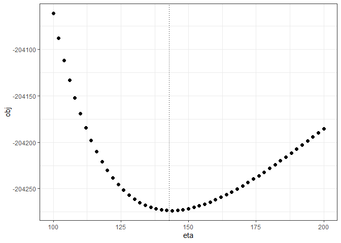

```r
theta_inv_vec <- seq(100, 200, 2)
plot_obj(theta, df_firm_reported, theta_inv_vec, 1)
```

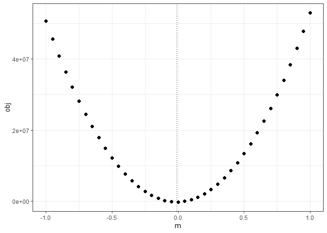

```r
m_vec <- seq(-1, 1, .05)
plot_obj(theta, df_firm_reported, m_vec, 2)
```

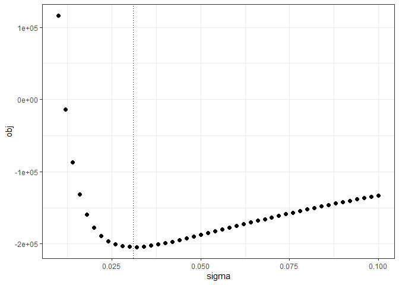

```r
sigma_vec <- seq(0.01, .1, .002)
plot_obj(theta, df_firm_reported, sigma_vec, 3)
```